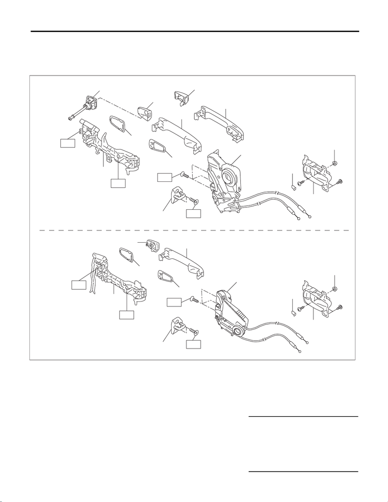

SL-2

General Description

SECURITY AND LOCKS

1. General Description

A: COMPONENT

1. DOOR LOCK ASSEMBLY

(A) Front (B) Rear

(1) Grommet - screw (8) Cover - handle front outer (driver’s

seat)

(15) Cover - handle rear outer

(2) Remote ASSY - door (9) Key lock - door (driver’s seat only) (16) Frame ASSY - rear door outer

(3) Cap remote (10) Spacer - door handle outer B

(4) Latch & actuator ASSY - front (11) Spacer - door handle outer A Tightening torque: N·m (kgf-m, ft-lb)

(5) Handle - door outer (model with

keyless access)

(12) Frame ASSY - front door outer T1: 6.5 (0.7, 4.8)

(6) Cover - handle front outer (pas-

senger’s seat)

(13) Striker - door T2: 7.5 (0.8, 5.5)

(7) Handle - door outer (model with-

out keyless access)

(14) Latch & actuator ASSY - rear T3: 18 (1.8, 13.3)

SL-01565

(14)

(2)

(2)

(1)

(3)

(4)

(13)

T3

(13)

T3

T1

T1

T2

(7)

(15)

(16)

T2

T2

(7)

(5)

(8)

(6)

(9)

(10)

(11)

(12)

T2

(A)

(B)

(10)

(11)

(1)

(3)

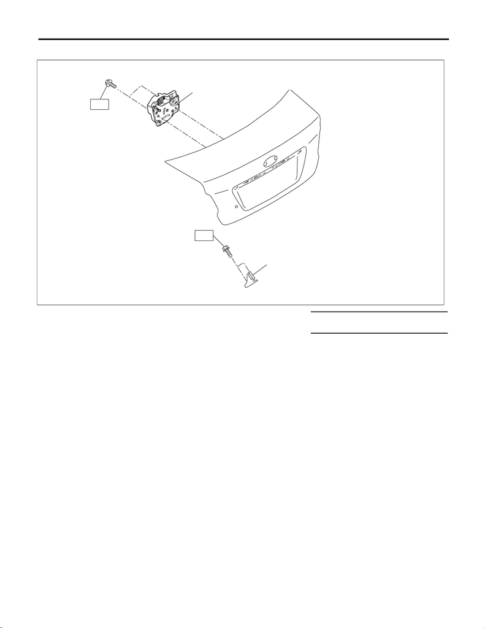

SL-3

General Description

SECURITY AND LOCKS

2. TRUNK LID LOCK

(1) Latch & actuator - trunk lid (2) Striker - trunk lid Tightening torque: N·m (kgf-m, ft-lb)

T: 7.5 (0.8, 5.5)

SL-02858

(2)

(1)

T

T

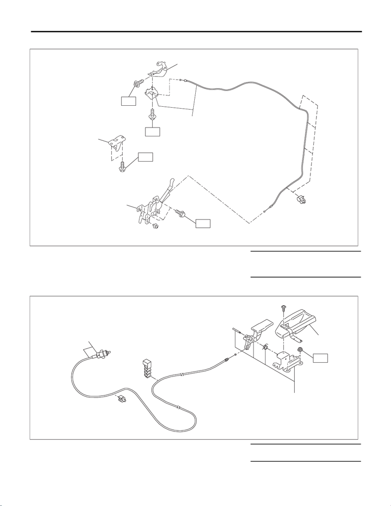

SL-4

General Description

SECURITY AND LOCKS

3. FRONT HOOD LOCK

4. REMOTE OPENER

(1) Lock ASSY - front hood (3) Bracket - opener handle Tightening torque: N·m (kgf-m, ft-lb)

(2) Cable - front hood (4) Striker - front hood T1: 7.5 (0.8, 5.5)

T2: 33 (3.4, 24.3)

(1) Cover - handle (3) Cable ASSY - fuel Tightening torque: N·m (kgf-m, ft-lb)

(2) Pull handle - opener T: 7.5 (0.8, 5.5)

SL-02894

(3)

(2)

(1)

(4)

T1

T1

T2

T2

SL-02859

(1)

(2)

(3)

T

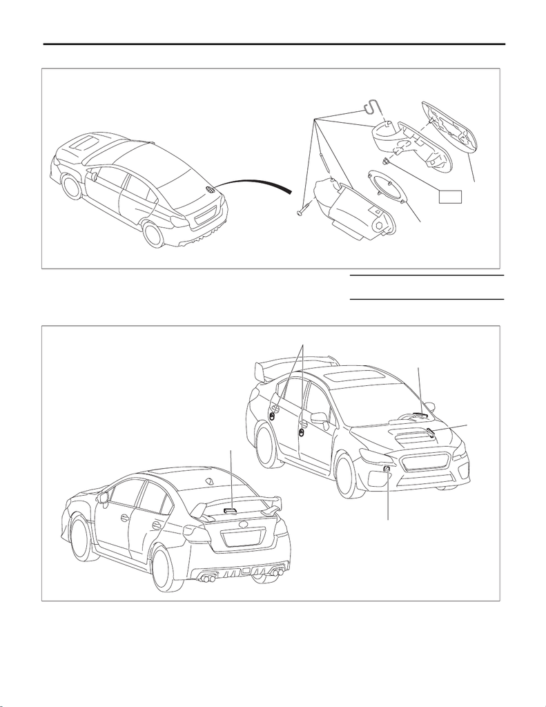

SL-5

General Description

SECURITY AND LOCKS

5. FUEL FLAP

6. KEYLESS ENTRY SYSTEM

(1) Saucer - COMPL (3) Ring clip Tightening torque: N·m (kgf-m, ft-lb)

(2) Flap - COMPL fuel T: 7.5 (0.8, 5.5)

(1) Door switch (3) Body integrated unit (5) Keyless entry control module

(2) Power window main switch (4) Keyless buzzer

SL-02893

(3)

(2)

(1)

T

SL-02860

(3)

(2)

(5)

(1)

(4)

[figure not shown]

SL-6

General Description

SECURITY AND LOCKS

7. SECURITY SYSTEM

8. KEYLESS ACCESS WITH PUSH BUTTON START SYSTEM

NOTE:

Refer to “Electrical Component Location” of “KEYLESS ACCESS WITH PUSH BUTTON START SYSTEM

(DIAGNOSTICS)” section. <Ref. to KPS(diag)-11, Electrical Component Location.>

B: CAUTION

• Before disassembling or reassembling parts, always disconnect the battery ground cable from battery.

When replacing the audio, control module and other parts provided with memory functions, record the mem-

ory contents before disconnecting the battery ground cable. Otherwise, the memory is cleared.

• If any immobilizer related part has been replaced, make sure to register the immobilizer.

• Be careful of the following items. Failing to do so may cause the airbag system malfunction.

– Yellow connectors and harnesses with yellow tapes around them are the connectors and harnesses for

the airbag system. When using a tester on these circuits, follow the cautions of “AIRBAG SYSTEM”. <Ref.

to AB-9, CAUTION, General Description.>

– Be careful not to damage the airbag system wiring harness when servicing the electrical parts around

the steering column.

• When removing, installing or replacing the VDCCM&H/U, VDCCM&H/U bracket, steering wheel or steer-

ing angle sensor (steering roll connector), perform “VDC sensor midpoint setting mode” of the VDC. <Ref. to

VDC-16, VDC SENSOR MIDPOINT SETTING MODE, ADJUSTMENT, VDC Control Module and Hydraulic

Control Unit (VDCCM&H/U).>

(1) Door switch (4) Horn (7) Impact sensor (driver’s seat instru-

ment panel side) (dealer option)

(2) Security indicator light (in combi-

nation meter)

(5) Body integrated unit

(3) Horn relay (in main fuse box) (6) Turn signal and hazard module

SL-02861

(1)

(2)

(3)

(4)

(5)(6)

(7)

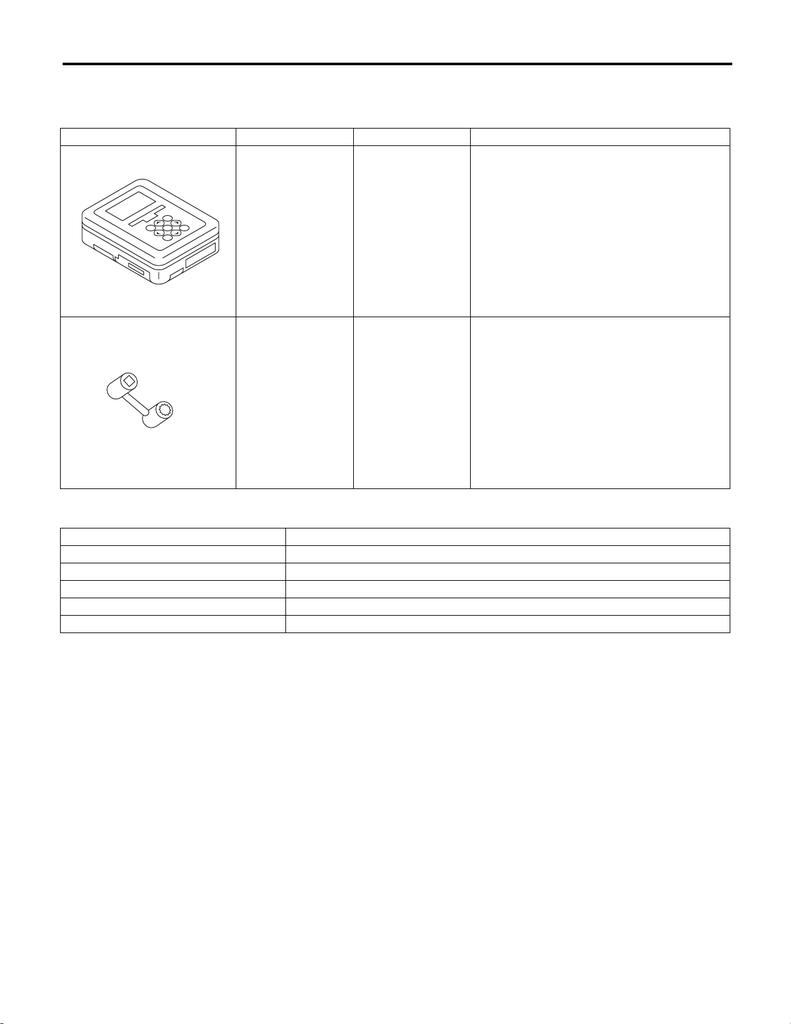

SL-7

General Description

SECURITY AND LOCKS

C: PREPARATION TOOL

1. SPECIAL TOOL

2. GENERAL TOOL

ILLUSTRATION TOOL NUMBER DESCRIPTION REMARKS

1B022XU0 SUBARU SELECT

MONITOR III KIT

Used for troubleshooting the electrical system.

NOTE:

For detailed operation procedures of SUBARU

SELECT MONITOR III KIT, refer to “PC applica-

tion help for Subaru Select Monitor”.

499987400 WRENCH COMPL Used for adjusting the lock assembly - front

hood.

TOOL NAME REMARKS

Circuit tester Used for measuring resistance and voltage.

Drill Used for replacing ignition key lock.

Reverse tap Used for replacing ignition key lock.

TORX

®

T30 Used for removing and installing door outer handle cover and frame assembly.

Clip remover Used for removing trim clip.

ST1B022XU0

ST499987400